# Interpretable forecasting models

**Joaquín Amat Rodrigo, Javier Escobar Ortiz**

*July, 2024 (last update November 2024)*

**More about forecasting**

- [ARIMA and SARIMAX models with python](https://cienciadedatos.net/documentos/py51-arima-sarimax-models-python.html)
- [Time series forecasting with machine learning](https://cienciadedatos.net/documentos/py27-time-series-forecasting-python-scikitlearn.html)
- [Forecasting time series with gradient boosting: XGBoost, LightGBM and CatBoost](https://www.cienciadedatos.net/documentos/py39-forecasting-time-series-with-skforecast-xgboost-lightgbm-catboost.html)
- [Forecasting time series with XGBoost](https://cienciadedatos.net/documentos/py56-forecasting-time-series-with-xgboost.html)
- [Global Forecasting Models: Multi-series forecasting](https://www.cienciadedatos.net/documentos/py44-multi-series-forecasting-skforecast.html)
- [Global Forecasting Models: Comparative Analysis of Single and Multi-Series Forecasting Modeling](https://cienciadedatos.net/documentos/py53-global-forecasting-models.html)
- [Probabilistic forecasting](https://www.cienciadedatos.net/documentos/py42-probabilistic-forecasting.html)
- [Forecasting with deep learning](https://www.cienciadedatos.net/documentos/py54-forecasting-with-deep-learning.html)
- [Forecasting energy demand with machine learning](https://www.cienciadedatos.net/documentos/py29-forecasting-electricity-power-demand-python.html)
- [Forecasting web traffic with machine learning](https://www.cienciadedatos.net/documentos/py37-forecasting-web-traffic-machine-learning.html)
- [Intermittent demand forecasting](https://www.cienciadedatos.net/documentos/py48-intermittent-demand-forecasting)
- [Modelling time series trend with tree-based models](https://www.cienciadedatos.net/documentos/py49-modelling-time-series-trend-with-tree-based-models.html)
- [Bitcoin price prediction with Python](https://www.cienciadedatos.net/documentos/py41-forecasting-cryptocurrency-bitcoin-machine-learning-python.html)
- [Stacking ensemble of machine learning models to improve forecasting](https://cienciadedatos.net/documentos/py52-stacking-ensemble-models-forecasting.html)
- [Interpretable forecasting models](https://cienciadedatos.net/documentos/py57-interpretable-forecasting-models.html)
- [Mitigating the Impact of Covid on forecasting Models](https://cienciadedatos.net/documentos/py45-weighted-time-series-forecasting.html)
- [Forecasting time series with missing values](https://cienciadedatos.net/documentos/py46-forecasting-time-series-missing-values.html)

[figure not shown]

## Introduction

Machine learning interpretability, also known as explainability, refers to the ability to understand, interpret, and explain the decisions or predictions made by machine learning models in a human-understandable way. It aims to shed light on how a model arrives at a particular result or decision.

Due to the complex nature of many modern machine learning models, such as ensemble methods, they often function as black boxes, making it difficult to understand why a particular prediction was made. Explanability techniques aim to demystify these models, providing insight into their inner workings and helping to build trust, improve transparency, and meet regulatory requirements in various domains. Improving model explainability not only helps to understand model behavior, but also helps to identify biases, improve model performance, and enable stakeholders to make more informed decisions based on machine learning insights.

The [**skforecast**](https://skforecast.org/) library is compatible with some of the most used interpretability methods: Shap values, Partial Dependency Plots and Model-specific methods.

## Libraries

Libraries used in this document.

```python
# Data manipulation
# ==============================================================================
import pandas as pd
import numpy as np
from skforecast.datasets import fetch_dataset

# Plotting
# ==============================================================================
import matplotlib.pyplot as plt
import shap
from skforecast.plot import set_dark_theme

# Modeling and forecasting
# ==============================================================================
import sklearn
import lightgbm
import skforecast
from sklearn.inspection import PartialDependenceDisplay
from lightgbm import LGBMRegressor
from skforecast.recursive import ForecasterRecursive
from skforecast.preprocessing import RollingFeatures

color = '\033[1m\033[38;5;208m'
print(f"{color}Version skforecast: {skforecast.__version__}")
print(f"{color}Version scikit-learn: {sklearn.__version__}")
print(f"{color}Version lightgbm: {lightgbm.__version__}")
print(f"{color}Version pandas: {pd.__version__}")
print(f"{color}Version numpy: {np.__version__}")
```

```
Version skforecast: 0.14.0
Version scikit-learn: 1.5.2
Version lightgbm: 4.4.0
Version pandas: 2.2.3
Version numpy: 2.0.2
```

## Data

```python
# Download data
# ==============================================================================
data = fetch_dataset(name="vic_electricity")
data.head(3)
```

```
vic_electricity
---------------
Half-hourly electricity demand for Victoria, Australia
O'Hara-Wild M, Hyndman R, Wang E, Godahewa R (2022).tsibbledata: Diverse
Datasets for 'tsibble'. https://tsibbledata.tidyverts.org/,
https://github.com/tidyverts/tsibbledata/.
https://tsibbledata.tidyverts.org/reference/vic_elec.html
Shape of the dataset: (52608, 4)
```

| Time | Demand | Temperature | Date | Holiday |
| --- | --- | --- | --- | --- |
| 2011-12-31 13:00:00 | 4382.825174 | 21.40 | 2012-01-01 | True |
| 2011-12-31 13:30:00 | 4263.365526 | 21.05 | 2012-01-01 | True |
| 2011-12-31 14:00:00 | 4048.966046 | 20.70 | 2012-01-01 | True |

```python
# Aggregation to daily frequency
# ==============================================================================
data = data.resample('D').agg({'Demand': 'sum', 'Temperature': 'mean'})
data.head(3)
```

| Time | Demand | Temperature |
| --- | --- | --- |
| 2011-12-31 | 82531.745918 | 21.047727 |
| 2012-01-01 | 227778.257304 | 26.578125 |
| 2012-01-02 | 275490.988882 | 31.751042 |

```python
# Create calendar variables
# ==============================================================================
data['day_of_week'] = data.index.dayofweek
data['month'] = data.index.month
data.head(3)
```

| Time | Demand | Temperature | day_of_week | month |
| --- | --- | --- | --- | --- |
| 2011-12-31 | 82531.745918 | 21.047727 | 5 | 12 |
| 2012-01-01 | 227778.257304 | 26.578125 | 6 | 1 |
| 2012-01-02 | 275490.988882 | 31.751042 | 0 | 1 |

```python
# Split train-test
# ==============================================================================
end_train = '2014-12-01 23:59:00'
data_train = data.loc[: end_train, :]
data_test  = data.loc[end_train:, :]
print(f"Dates train : {data_train.index.min()} --- {data_train.index.max()}  (n={len(data_train)})")
print(f"Dates test  : {data_test.index.min()} --- {data_test.index.max()}  (n={len(data_test)})")
```

```
Dates train : 2011-12-31 00:00:00 --- 2014-12-01 00:00:00  (n=1067)
Dates test  : 2014-12-02 00:00:00 --- 2014-12-31 00:00:00  (n=30)
```

## Forecasting model

A forecasting model is created to predict the energy demand using the past 7 values (last week) and the temperature as an exogenous variable.

```python
# Create a recursive multi-step forecaster (ForecasterAutoreg)
# ==============================================================================
window_features = RollingFeatures(stats=['mean'], window_sizes=24)
exog_features = ['Temperature', 'day_of_week', 'month']
forecaster = ForecasterRecursive(
                 regressor       = LGBMRegressor(random_state=123, verbose=-1),
                 lags            = 7,
                 window_features = window_features
             )

forecaster.fit(
    y    = data_train['Demand'],
    exog = data_train[exog_features],
)
forecaster
```

ForecasterRecursive

**General Information**

- **Regressor:** LGBMRegressor(random_state=123, verbose=-1)

- **Lags:** [1 2 3 4 5 6 7]

- **Window features:** ['roll_mean_24']

- **Window size:** 24

- **Exogenous included:** True

- **Weight function included:** False

- **Differentiation order:** None

- **Creation date:** 2024-11-05 13:04:27

- **Last fit date:** 2024-11-05 13:04:27

- **Skforecast version:** 0.14.0

- **Python version:** 3.12.4

- **Forecaster id:** None

**Exogenous Variables**

Temperature, day_of_week, month

**Data Transformations**

- **Transformer for y:** None

- **Transformer for exog:** None

**Training Information**

- **Training range:** [Timestamp('2011-12-31 00:00:00'), Timestamp('2014-12-01 00:00:00')]

- **Training index type:** DatetimeIndex

- **Training index frequency:** D

**Regressor Parameters**

{'boosting_type': 'gbdt', 'class_weight': None, 'colsample_bytree': 1.0, 'importance_type': 'split', 'learning_rate': 0.1, 'max_depth': -1, 'min_child_samples': 20, 'min_child_weight': 0.001, 'min_split_gain': 0.0, 'n_estimators': 100, 'n_jobs': None, 'num_leaves': 31, 'objective': None, 'random_state': 123, 'reg_alpha': 0.0, 'reg_lambda': 0.0, 'subsample': 1.0, 'subsample_for_bin': 200000, 'subsample_freq': 0, 'verbose': -1}

**Fit Kwargs**

{}

[🛈 **API Reference**](https://skforecast.org/0.14.0/api/forecasterrecursive.html) [🗎 **User Guide**](https://skforecast.org/0.14.0/user_guides/autoregresive-forecaster.html)

## Model-specific feature importances

Feature importance in machine learning determines the relevance or importance of each feature (or variable) in a model's prediction. In other words, it measures how much each feature contributes to the model's output.

Feature importance can be used for several purposes, such as identifying the most relevant features for a given prediction, understanding the behavior of a model, and selecting the best set of features for a given task. It can also help to identify potential biases or errors in the data used to train the model. It is important to note that feature importance is not a definitive measure of causality. Just because a feature is identified as important does not necessarily mean that it caused the outcome. Other factors, such as confounding variables, may also be at play.

The method used to calculate feature importance may vary depending on the type of machine learning model used. Different models can have different assumptions and characteristics that affect the importance calculation. For example, decision tree-based models, such as Random Forest and Gradient Boosting, typically use methods that measure the reduction of impurities or the effect of permutations. Linear regression models typically use coefficients. The magnitude of the coefficient reflects the strength and direction of the relationship between the predictor and the target variable.

The importance of the predictors included in a forecaster can be obtained using the method `get_feature_importances()`. This method accesses the `coef_` and `feature_importances_` attributes of the internal regressor.

**⚠ Warning**

The `get_feature_importances()` method will only return values if the forecaster's regressor has either the `coef_` or `feature_importances_` attribute, which is the default in scikit-learn.

```python
# Extract feature importance
# ==============================================================================
importance = forecaster.get_feature_importances()
importance
```

|  | feature | importance |
| --- | --- | --- |
| 8 | Temperature | 568 |
| 0 | lag_1 | 426 |
| 1 | lag_2 | 291 |
| 6 | lag_7 | 248 |
| 4 | lag_5 | 243 |
| 2 | lag_3 | 236 |
| 7 | roll_mean_24 | 227 |
| 10 | month | 224 |
| 5 | lag_6 | 200 |
| 3 | lag_4 | 177 |
| 9 | day_of_week | 160 |

## Shap Values

SHAP (SHapley Additive exPlanations) values are a popular method for explaining machine learning models, as they help to understand how variables and values influence predictions visually and quantitatively.

It is possible to generate SHAP-values explanations from skforecast models with just two essential elements:

- The internal regressor of the forecaster.
- The training matrices created from the time series and used to fit the forecaster.

By leveraging these two components, users can create insightful and interpretable explanations for their skforecast models. These explanations can be used to verify the reliability of the model, identify the most significant factors that contribute to model predictions, and gain a deeper understanding of the underlying relationship between the input variables and the target variable.

### Shap explainer and training matrices

```python
# Training matrices used by the forecaster to fit the internal regressor
# ==============================================================================
X_train, y_train = forecaster.create_train_X_y(
                       y    = data_train['Demand'],
                       exog = data_train[exog_features],
                   )

display(X_train.head(3))
```

| Time | lag_1 | lag_2 | lag_3 | lag_4 | lag_5 | lag_6 | lag_7 | roll_mean_24 | Temperature | day_of_week | month |
| --- | --- | --- | --- | --- | --- | --- | --- | --- | --- | --- | --- |
| 2012-01-24 | 280188.298774 | 239810.374218 | 207949.859910 | 225035.325476 | 240187.677944 | 247722.494256 | 292458.685446 | 222658.202570 | 26.611458 | 1.0 | 1.0 |
| 2012-01-25 | 287474.816646 | 280188.298774 | 239810.374218 | 207949.859910 | 225035.325476 | 240187.677944 | 247722.494256 | 231197.497184 | 19.759375 | 2.0 | 1.0 |
| 2012-01-26 | 239083.684380 | 287474.816646 | 280188.298774 | 239810.374218 | 207949.859910 | 225035.325476 | 240187.677944 | 231668.556646 | 20.038542 | 3.0 | 1.0 |

```python
# Create SHAP explainer (for three base models)
# ==============================================================================
explainer = shap.TreeExplainer(forecaster.regressor)

# Sample 50% of the data to speed up the calculation
rng = np.random.default_rng(seed=785412)
sample = rng.choice(X_train.index, size=int(len(X_train)*0.5), replace=False)
X_train_sample = X_train.loc[sample, :]
shap_values = explainer.shap_values(X_train_sample)
```

**✎ Note**

Shap library has several explainers, each designed for a different type of model. The `shap.TreeExplainer` explainer is used for tree-based models, such as the `LGBMRegressor` used in this example. For more information, see the [SHAP documentation](https://shap.readthedocs.io/en/latest/tabular_examples.html).

### SHAP Summary Plot

The SHAP summary plot typically displays the feature importance or contribution of each feature to the model's output across multiple data points. It shows how much each feature contributes to pushing the model's prediction away from a base value (often the model's average prediction). By examining a SHAP summary plot, one can gain insights into which features have the most significant impact on predictions, whether they positively or negatively influence the outcome, and how different feature values contribute to specific predictions.

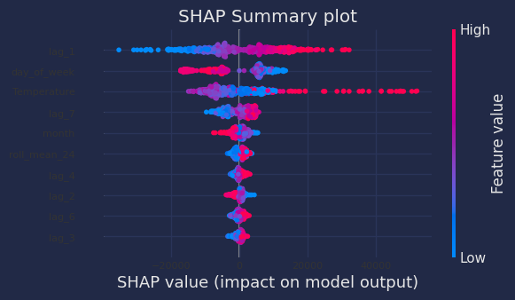

```python
# Shap summary plot (top 10)
# ==============================================================================
shap.initjs()
shap.summary_plot(shap_values, X_train_sample, max_display=10, show=False)
fig, ax = plt.gcf(), plt.gca()
ax.set_title("SHAP Summary plot")
ax.tick_params(labelsize=8)
fig.set_size_inches(6, 3)
```

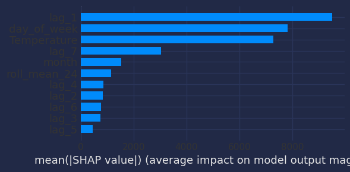

```python
shap.summary_plot(shap_values, X_train, plot_type="bar", plot_size=(6, 3))
```

### Explain predictions in training data

A `shap.force_plot` is a specific type of visualization that provides an interactive and detailed view of how individual features contribute to a particular prediction made by a machine learning model. It's a local interpretation tool that helps understand why a model made a specific prediction for a given instance.

**Visualize a single prediction**

```python
# Force plot for the first observation in the training set
# ==============================================================================
shap.force_plot(explainer.expected_value, shap_values[0,:], X_train_sample.iloc[0,:])
```

**Visualize many predictions**

```python
# Force plot for the first 200 observations in the training set
# ==============================================================================
shap.force_plot(explainer.expected_value, shap_values[:200, :], X_train_sample.iloc[:200, :])
```

### SHAP Dependence Plots

SHAP dependence plots are visualizations used to understand the relationship between a feature and the model output by displaying how the value of a single feature affects predictions made by the model while considering interactions with other features. These plots are particularly useful for examining how a certain feature impacts the model's predictions across its range of values while considering interactions with other variables.

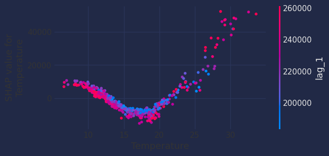

```python
# Dependence plot for Temperature
# ==============================================================================
fig, ax = plt.subplots(figsize=(6, 3))
shap.dependence_plot("Temperature", shap_values, X_train_sample, ax=ax)
```

### Explain forecasted values

It is also possible to use SHAP values to explain the forecasted values. It helps to understand why the model made a specific prediction for a date in the future.

```python
# Forecasting next 30 days
# ==============================================================================
predictions = forecaster.predict(steps=30, exog=data_test[exog_features])
predictions
```

```
2014-12-02    230878.900870
2014-12-03    230782.656189
2014-12-04    237992.220195
2014-12-05    204807.430451
2014-12-06    178976.825634
2014-12-07    189987.574968
2014-12-08    205003.377184
2014-12-09    203696.919024
2014-12-10    209051.236412
2014-12-11    209968.258997
2014-12-12    205781.805973
2014-12-13    195530.724715
2014-12-14    201915.375753
2014-12-15    223563.240369
2014-12-16    218723.730618
2014-12-17    218731.280255
2014-12-18    211443.910502
2014-12-19    201556.174129
2014-12-20    183424.934062
2014-12-21    206318.055051
2014-12-22    235697.634764
2014-12-23    221620.562404
2014-12-24    218372.992891
2014-12-25    219748.601630
2014-12-26    203865.864787
2014-12-27    181653.080277
2014-12-28    200849.858496
2014-12-29    212235.635255
2014-12-30    210632.512899
2014-12-31    219284.469160
Freq: D, Name: pred, dtype: float64
```

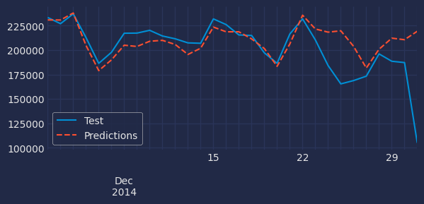

```python
# Plot predictions
# ==============================================================================
set_dark_theme()
fig, ax = plt.subplots(figsize=(6, 2.5))
data_test['Demand'].plot(ax=ax, label='Test')
predictions.plot(ax=ax, label='Predictions', linestyle='--')
ax.set_xlabel(None)
ax.legend();
```

The method `create_predict_X` is used to create the input matrix used internally by the forecaster's `predict` method. This matrix is then used to generate SHAP values for the forecasted values.

```python
# Create input matrix used by the predict method
# ==============================================================================
X_predict = forecaster.create_predict_X(steps=30, exog=data_test[exog_features])
X_predict
```

|  | lag_1 | lag_2 | lag_3 | lag_4 | lag_5 | lag_6 | lag_7 | roll_mean_24 | Temperature | day_of_week | month |
| --- | --- | --- | --- | --- | --- | --- | --- | --- | --- | --- | --- |
| 2014-12-02 | 237812.592388 | 234970.336660 | 189653.758108 | 202017.012448 | 214602.854760 | 218321.456402 | 214318.765210 | 211369.709659 | 19.833333 | 1.0 | 12.0 |
| 2014-12-03 | 230878.900870 | 237812.592388 | 234970.336660 | 189653.758108 | 202017.012448 | 214602.854760 | 218321.456402 | 212777.981610 | 19.616667 | 2.0 | 12.0 |
| 2014-12-04 | 230782.656189 | 230878.900870 | 237812.592388 | 234970.336660 | 189653.758108 | 202017.012448 | 214602.854760 | 214485.198829 | 21.702083 | 3.0 | 12.0 |
| 2014-12-05 | 237992.220195 | 230782.656189 | 230878.900870 | 237812.592388 | 234970.336660 | 189653.758108 | 202017.012448 | 215457.947659 | 18.352083 | 4.0 | 12.0 |
| 2014-12-06 | 204807.430451 | 237992.220195 | 230782.656189 | 230878.900870 | 237812.592388 | 234970.336660 | 189653.758108 | 214962.018955 | 17.356250 | 5.0 | 12.0 |
| 2014-12-07 | 178976.825634 | 204807.430451 | 237992.220195 | 230782.656189 | 230878.900870 | 237812.592388 | 234970.336660 | 213141.307938 | 16.175000 | 6.0 | 12.0 |
| 2014-12-08 | 189987.574968 | 178976.825634 | 204807.430451 | 237992.220195 | 230782.656189 | 230878.900870 | 237812.592388 | 210937.056718 | 17.747917 | 0.0 | 12.0 |
| 2014-12-09 | 205003.377184 | 189987.574968 | 178976.825634 | 204807.430451 | 237992.220195 | 230782.656189 | 230878.900870 | 210786.576389 | 17.050000 | 1.0 | 12.0 |
| 2014-12-10 | 203696.919024 | 205003.377184 | 189987.574968 | 178976.825634 | 204807.430451 | 237992.220195 | 230782.656189 | 211532.961206 | 18.504167 | 2.0 | 12.0 |
| 2014-12-11 | 209051.236412 | 203696.919024 | 205003.377184 | 189987.574968 | 178976.825634 | 204807.430451 | 237992.220195 | 212209.477689 | 17.968750 | 3.0 | 12.0 |
| 2014-12-12 | 209968.258997 | 209051.236412 | 203696.919024 | 205003.377184 | 189987.574968 | 178976.825634 | 204807.430451 | 212188.542641 | 21.441667 | 4.0 | 12.0 |
| 2014-12-13 | 205781.805973 | 209968.258997 | 209051.236412 | 203696.919024 | 205003.377184 | 189987.574968 | 178976.825634 | 212016.059027 | 26.131250 | 5.0 | 12.0 |
| 2014-12-14 | 195530.724715 | 205781.805973 | 209968.258997 | 209051.236412 | 203696.919024 | 205003.377184 | 189987.574968 | 210936.875468 | 19.918750 | 6.0 | 12.0 |
| 2014-12-15 | 201915.375753 | 195530.724715 | 205781.805973 | 209968.258997 | 209051.236412 | 203696.919024 | 205003.377184 | 209902.060260 | 19.920833 | 0.0 | 12.0 |
| 2014-12-16 | 223563.240369 | 201915.375753 | 195530.724715 | 205781.805973 | 209968.258997 | 209051.236412 | 203696.919024 | 210653.141682 | 19.250000 | 1.0 | 12.0 |
| 2014-12-17 | 218723.730618 | 223563.240369 | 201915.375753 | 195530.724715 | 205781.805973 | 209968.258997 | 209051.236412 | 211786.711094 | 17.675000 | 2.0 | 12.0 |
| 2014-12-18 | 218731.280255 | 218723.730618 | 223563.240369 | 201915.375753 | 195530.724715 | 205781.805973 | 209968.258997 | 212502.799259 | 16.520833 | 3.0 | 12.0 |
| 2014-12-19 | 211443.910502 | 218731.280255 | 218723.730618 | 223563.240369 | 201915.375753 | 195530.724715 | 205781.805973 | 212022.176837 | 16.543750 | 4.0 | 12.0 |
| 2014-12-20 | 201556.174129 | 211443.910502 | 218731.280255 | 218723.730618 | 223563.240369 | 201915.375753 | 195530.724715 | 211490.402208 | 18.506250 | 5.0 | 12.0 |
| 2014-12-21 | 183424.934062 | 201556.174129 | 211443.910502 | 218731.280255 | 218723.730618 | 223563.240369 | 201915.375753 | 210036.380444 | 24.031250 | 6.0 | 12.0 |
| 2014-12-22 | 206318.055051 | 183424.934062 | 201556.174129 | 211443.910502 | 218731.280255 | 218723.730618 | 223563.240369 | 209691.180456 | 22.950000 | 0.0 | 12.0 |
| 2014-12-23 | 235697.634764 | 206318.055051 | 183424.934062 | 201556.174129 | 211443.910502 | 218731.280255 | 218723.730618 | 211094.539720 | 18.829167 | 1.0 | 12.0 |
| 2014-12-24 | 221620.562404 | 235697.634764 | 206318.055051 | 183424.934062 | 201556.174129 | 211443.910502 | 218731.280255 | 212426.489899 | 18.312500 | 2.0 | 12.0 |
| 2014-12-25 | 218372.992891 | 221620.562404 | 235697.634764 | 206318.055051 | 183424.934062 | 201556.174129 | 211443.910502 | 211734.933908 | 16.933333 | 3.0 | 12.0 |
| 2014-12-26 | 219748.601630 | 218372.992891 | 221620.562404 | 235697.634764 | 206318.055051 | 183424.934062 | 201556.174129 | 210982.267627 | 16.429167 | 4.0 | 12.0 |
| 2014-12-27 | 203865.864787 | 219748.601630 | 218372.992891 | 221620.562404 | 235697.634764 | 206318.055051 | 183424.934062 | 209856.724457 | 18.189583 | 5.0 | 12.0 |
| 2014-12-28 | 181653.080277 | 203865.864787 | 219748.601630 | 218372.992891 | 221620.562404 | 235697.634764 | 206318.055051 | 207809.658794 | 24.539583 | 6.0 | 12.0 |
| 2014-12-29 | 200849.858496 | 181653.080277 | 203865.864787 | 219748.601630 | 218372.992891 | 221620.562404 | 235697.634764 | 206262.060389 | 17.677083 | 0.0 | 12.0 |
| 2014-12-30 | 212235.635255 | 200849.858496 | 181653.080277 | 203865.864787 | 219748.601630 | 218372.992891 | 221620.562404 | 206571.568923 | 17.391667 | 1.0 | 12.0 |
| 2014-12-31 | 210632.512899 | 212235.635255 | 200849.858496 | 181653.080277 | 203865.864787 | 219748.601630 | 218372.992891 | 207890.555892 | 21.034615 | 2.0 | 12.0 |

```python
# SHAP values for the predictions
# ==============================================================================
shap_values = explainer.shap_values(X_predict)
```

**Visualize a single forecasted date**

```python
# Force plot for a specific forecasted date
# ==============================================================================
predicted_date = '2014-12-08'
iloc_predicted_date = X_predict.index.get_loc(predicted_date)
shap.force_plot(
    explainer.expected_value,
    shap_values[iloc_predicted_date,:],
    X_predict.iloc[iloc_predicted_date,:]
)
```

**Visualize many forecasted dates**

```python
# Force plot for all forecasted dates
# ==============================================================================
shap.force_plot(explainer.expected_value, shap_values, X_predict)
```

## Scikit-learn partial dependence plots

The resulting plots show how changes in the selected feature(s) affect the predicted outcome while holding other features constant on average. Remember that these plots should be interpreted in the context of your model and data. They provide insight into the relationship between specific features and the model's predictions.

A more detailed description of the Partial Dependency Plot can be found in [Scikitlearn's User Guides](https://scikit-learn.org/stable/modules/partial_dependence.html#partial-dependence-and-individual-conditional-expectation-plots).

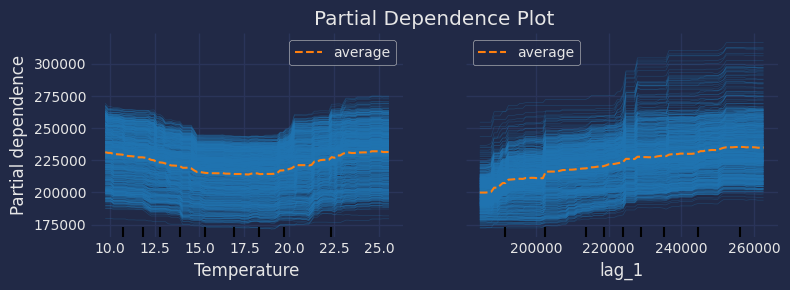

```python
# Scikit-learn partial dependence plots
# ==============================================================================
fig, ax = plt.subplots(figsize=(8, 3))
pd.plots = PartialDependenceDisplay.from_estimator(
    estimator = forecaster.regressor,
    X         = X_train,
    features  = ["Temperature", "lag_1"],
    kind      = 'both',
    ax        = ax,
)
ax.set_title("Partial Dependence Plot")
fig.tight_layout();
```

## Session information

```python
import session_info
session_info.show(html=False)
```

```
-----
lightgbm            4.4.0
matplotlib          3.9.0
numpy               2.0.2
pandas              2.2.3
session_info        1.0.0
shap                0.46.0
skforecast          0.14.0
sklearn             1.5.2
-----
IPython             8.25.0
jupyter_client      8.6.2
jupyter_core        5.7.2
notebook            6.4.12
-----
Python 3.12.4 | packaged by Anaconda, Inc. | (main, Jun 18 2024, 15:03:56) [MSC v.1929 64 bit (AMD64)]
Windows-11-10.0.26100-SP0
-----
Session information updated at 2024-11-05 13:04
```

## Citation

**How to cite this document**

If you use this document or any part of it, please acknowledge the source, thank you!

Interpretable forecasting models by Joaquín Amat Rodrigo and Javier Escobar Ortiz, available under a Attribution-NonCommercial-ShareAlike 4.0 International at https://www.cienciadedatos.net/documentos/py57-interpretable-forecasting-models.html

**How to cite skforecast**

If you use skforecast for a scientific publication, we would appreciate it if you cite the published software.

Zenodo:

Amat Rodrigo, Joaquin, & Escobar Ortiz, Javier. (2024). skforecast (v0.14.0). Zenodo. https://doi.org/10.5281/zenodo.8382788

APA:

Amat Rodrigo, J., & Escobar Ortiz, J. (2024). skforecast (Version 0.14.0) [Computer software]. https://doi.org/10.5281/zenodo.8382788

BibTeX:

@software{skforecast, author = {Amat Rodrigo, Joaquin and Escobar Ortiz, Javier}, title = {skforecast}, version = {0.14.0}, month = {11}, year = {2024}, license = {BSD-3-Clause}, url = {https://skforecast.org/}, doi = {10.5281/zenodo.8382788} }

This work by Joaquín Amat Rodrigo and Javier Escobar Ortiz is licensed under a [Attribution-NonCommercial-ShareAlike 4.0 International](https://creativecommons.org/licenses/by-nc-sa/4.0/).